# HousePrice

Kun He

17/9/2017

## Introduction

The task of business analysts in house agencies is to estimate the value of a house. This is often based different features of a house including building years, how large is the house, which area is the house located, etc. A predictive model will be built based on the data downloaded online on 14/9/2017.

## Data Details

The data set contains 2410 properties in the city of Amsterdam. The dataset itself is not clean enough yet for an instant analysis. Missing variables are also possible for some features. A preliminary data cleaning and understanding is required. There are 11 columns for each property. Adress: the address for the property Post: the post code of the property Price: the price of the property Date: the date when the property was shown on the website Construction year: the year when the property was built Living area: the area of the living area in the unit of m2 Volume: the volume of the property in the unit of m3 Facilities: the relevant facilities Energy: the energy label of the property Parking: availability of parking

## Data Cleaning

The data is too messy at first glance, summary statistics cannot be done dirrectly. It is necessary to first clean the data then move to exploration.

```r
data <- read.csv("house_price.csv")
colnames(data)[1] <- "ID"
colnames(data)[2] <- "address"
colnames(data)[6] <- "constryr"

head(data)
```

```
##   ID                                       address              post
## 1  1  Erich Salomonstraat 517    1087 GT Amsterdam 1087 GT Amsterdam
## 2  2   J.F. Ankersmitstraat 8    1068 JX Amsterdam 1068 JX Amsterdam
## 3  3          Rapha雔plein 39    1077 PX Amsterdam 1077 PX Amsterdam
## 4  4          Lisdoddelaan 51    1087 KB Amsterdam 1087 KB Amsterdam
## 5  5     P. Lieftinckstraat 7    1067 VW Amsterdam 1067 VW Amsterdam
## 6  6 Visseringstraat 7 III/IV    1051 KG Amsterdam 1051 KG Amsterdam
##              price      date
## 1   € 599,000 k.k.     Today
## 2   € 450,000 k.k.  8-Sep-17
## 3 € 1,995,000 k.k.   2 weeks
## 4 € 1,550,000 k.k.   6 weeks
## 5   € 298,011 k.k.  2 months
## 6   € 399,000 k.k. 12-Sep-17
##                                                       constryr living_area
```

[output cut: 27 more lines]

```r
# check numbers of rows and columns
dim(data)
```

```
## [1] 2410   12
```

```r
# check names of data
names(data)
```

```
##  [1] "ID"          "address"     "post"        "price"       "date"
##  [6] "constryr"    "living_area" "volume"      "nr_rooms"    "facilities"
## [11] "energy"      "parking"
```

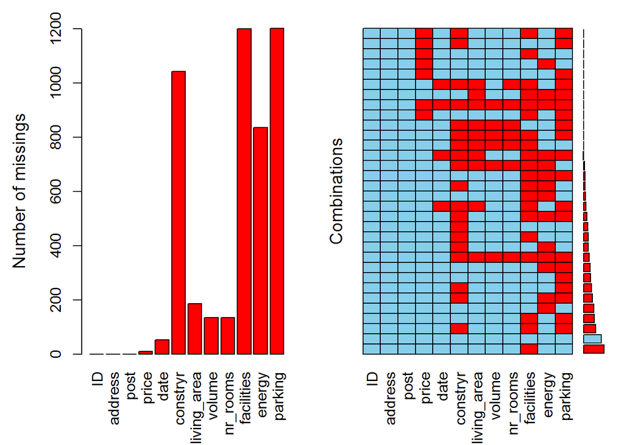

```r
# check missing values
aggr(data, prop=FALSE,numbers=TRUE)
```

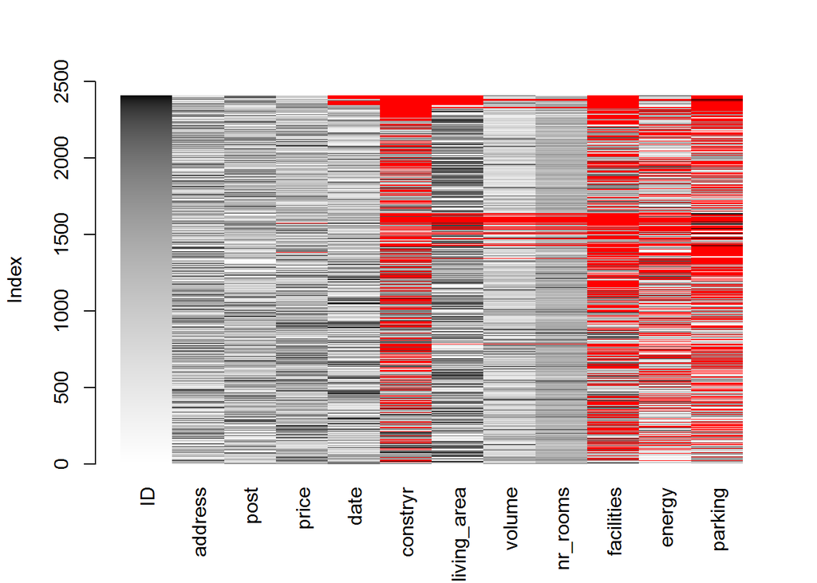

```r
matrixplot(data)
```

First of all, remove the observations with either too many missing variables or missing prices.

```r
# Remove observations with more than 50% missing columns
data <- data[-manyNAs(data, 0.5), ]

# Remove the rows with price as NA
data <- data[!is.na(data$price),]

# Remove the rows with "Price on request"
data <- data[-grep("Price on request", data$price),]

dim(data)
```

```
## [1] 2295   12
```

Since price is the dependent variables, recode it into numeric variables first. Two types of prices are involved: “v.o.n.” and “k.k.”. Introduce also a price type variable

```r
data$price1 <- data$price
data$price1 <- substr(data$price1,3,100)
data$price1[grep(" v.o.n.", data$price1)] <- gsub('( v.o.n..*)', '', data$price1[grep(" v.o.n.", data$price1)])
data$price1[grep(" k.k.", data$price1)] <- gsub('( k.k..*)', '', data$price1[grep(" k.k.", data$price1)])
data$price1 <- gsub(',', '', data$price1)
data$price1 <- as.integer(data$price1)

# check still mising price
table(is.na(data$price1))
```

```
##
## FALSE
##  2295
```

```r
data$price_type <- ""
data$price_type[grep(" v.o.n.", data$price)] <- "v.o.n."
data$price_type[grep(" k.k.", data$price)] <- "k.k."

table(data$price_type)
```

```
##
##   k.k. v.o.n.
##   2178    117
```

```r
# check still mising price_type
table(is.na(data$price1))
```

```
##
## FALSE
##  2295
```

Then clean the information of all the features for prediction.

```r
# living area
data$living_area_ori <- data$living_area
data$living_area <- gsub(',', '', data$living_area)
data$living_area <- as.integer(data$living_area)

# check still mising living_area
table(is.na(data$living_area))
```

```
##
## FALSE  TRUE
##  2213    82
```

```r
# volume
data$volume_ori <- data$living_area
data$volume <- gsub(',', '', data$volume)
data$volume <- as.integer(data$volume)
dim(data[!is.na(data$volume),])
```

```
## [1] 2263   16
```

```r
# check still mising volume
table(is.na(data$volume))
```

```
##
## FALSE  TRUE
##  2263    32
```

```r
# number of rooms
data$nr_rooms_ori <- data$nr_rooms
data$nr_rooms <- gsub('( room.*)', '', data$nr_rooms)
data$nr_rooms <- as.integer(data$nr_rooms)

# check still mising nr_rooms
table(is.na(data$nr_rooms))
```

```
##
## FALSE  TRUE
##  2262    33
```

```r
# number of bedrooms
data$facilities_full <- paste(gsub('(.*\\()', '', data$nr_rooms_ori), data$facilities)
data$nr_bedrooms <- data$facilities_full
data$nr_bedrooms <- gsub('(bedroom.*)', '', data$nr_bedrooms)
data$nr_bedrooms[-grep('(bedroom.*)', data$nr_bedrooms)] <- NA
data$nr_bedrooms <- as.integer(data$nr_bedrooms)

# check still mising bedrooms
table(is.na(data$nr_rooms))
```

```
##
## FALSE  TRUE
##  2262    33
```

```r
# construction year

data$constryr1 <- data$constryr
data$constryr1 <- substr(data$constryr1, 1, 6)
data$constryr1[grep("After",data$constryr)] <- substr(data$constryr[grep("After",data$constryr1)],7,12)
data$constryr1[grep("Before",data$constryr)] <- substr(data$constryr[grep("Before",data$constryr1)],8,13)
data$constryr1[grep("period",data$constryr)] <- substr(data$constryr[grep("period",data$constryr1)],8,19)
data$constryr2 <- data$constryr1
data$constryr1[grep("period",data$constryr)] <- NA
data$constryr1 <- as.integer(data$constryr1)
data$constryr1[grep("-",data$constryr2)] <- round((as.numeric(gsub('(.*-)', '', data$constryr2[grep("-",data$constryr2)])) + as.numeric(gsub('(-.*)', '', data$constryr2[grep("-",data$constryr2)]))) / 2 ,0)

# check still mising construction year
table(is.na(data$constryr1))
```

```
##
## FALSE  TRUE
##  1360   935
```

```r
# location
data$PC4 <- substr(data$post,1,3)
# considering too many levels, use only 3 digit of postcode
data$PC4[data$PC4=="104"] <- "103"
table(data$PC4)
```

```
##
## 101 102 103 105 106 107 108 109 110
## 526  92 101 419 350 313 179 189 126
```

```r
# check still mising location
table(is.na(data$PC4))
```

```
##
## FALSE
##  2295
```

```r
# energy label
data$energy_label <- data$energy
data$energy_label <- substr(data$energy,1,1)
# if still missing then unknown
data$energy_label[is.na(data$energy_label)] <- "Unknown"
table(data$energy_label)
```

```
##
##       A       B       C       D       E       F       G Unknown
##     331     230     343     175     208      84     194     730
```

```r
# parking
table(data$parking)
```

```
##
##               Paid Parking garage and             Public
##                494                  1                686
##        Underground
##                 25
```

```r
table(is.na(data$parking))
```

```
##
## FALSE  TRUE
##  1206  1089
```

```r
data$parking <- as.character(data$parking)
# if still missing then Unknown
data$parking[is.na(data$parking)] <- "Unknown"
data$parking[data$parking=="Parking garage and"] <- "Unknown"
table(data$parking)
```

```
##
##        Paid      Public Underground     Unknown
##         494         686          25        1090
```

```r
# date
data$date <- as.character(data$date)
data$daystillnow[data$date=="Today"] <- as.integer(Sys.Date()) - as.integer(as.Date("2017-09-14"))
data$daystillnow[grep("weeks",data$date)] <- as.integer(substr(data$date[grep("weeks",data$date)],1,1))*7
data$daystillnow[grep("months",data$date)] <- as.integer(substr(data$date[grep("months",data$date)],1,1))*30
data$daystillnow[grep("September 7, 2017",data$date)] <- as.integer(Sys.Date()) - as.integer(as.Date("2017-09-07"))
data$daystillnow[is.na(data$daystillnow) & !is.na(data$date)] <- as.integer(Sys.Date()) - as.integer(as.Date(data$date[is.na(data$daystillnow) & !is.na(data$date)], format="%d-%b-%y"))
# if still missing then today
data$daystillnow[is.na(data$daystillnow)] <- as.integer(Sys.Date()) - as.integer(as.Date("2017-09-14"))
```

## Exploration and feature energering

It is always important to explore the relationship between features and dependent variable.

```r
# names(data)
# data_backup <- data
# data <- data_backup
data <- data[,c("price1","price_type","living_area","volume","nr_rooms","nr_bedrooms","energy_label","parking","constryr1","PC4","daystillnow")]
# names(data)
summary(data)
```

```
##      price1          price_type         living_area         volume
##  Min.   :    7000   Length:2295        Min.   :  20.0   Min.   :  27.0
##  1st Qu.:  275000   Class :character   1st Qu.:  67.0   1st Qu.: 205.0
##  Median :  399000   Mode  :character   Median :  92.0   Median : 281.0
##  Mean   :  606717                      Mean   : 109.8   Mean   : 352.3
##  3rd Qu.:  625000                      3rd Qu.: 130.0   3rd Qu.: 415.0
##  Max.   :24700000                      Max.   :1047.0   Max.   :3760.0
##                                        NA's   :82       NA's   :32
##     nr_rooms      nr_bedrooms     energy_label         parking
##  Min.   : 1.00   Min.   : 1.000   Length:2295        Length:2295
##  1st Qu.: 3.00   1st Qu.: 2.000   Class :character   Class :character
##  Median : 3.00   Median : 2.000   Mode  :character   Mode  :character
##  Mean   : 3.82   Mean   : 2.498
##  3rd Qu.: 4.00   3rd Qu.: 3.000
##  Max.   :20.00   Max.   :13.000
##  NA's   :33      NA's   :98
##    constryr1        PC4             daystillnow
##  Min.   :1625   Length:2295        Min.   :  4.0
##  1st Qu.:1919   Class :character   1st Qu.: 13.0
##  Median :1966   Mode  :character   Median : 35.0
##  Mean   :1957                      Mean   : 49.8
##  3rd Qu.:1999                      3rd Qu.: 60.0
##  Max.   :2019                      Max.   :180.0
##  NA's   :935
```

```r
str(data)
```

```
## 'data.frame':    2295 obs. of  11 variables:
##  $ price1      : int  599000 450000 1995000 1550000 298011 399000 325000 295000 250000 275000 ...
##  $ price_type  : chr  "k.k." "k.k." "k.k." "k.k." ...
##  $ living_area : int  173 143 250 310 102 70 55 97 57 70 ...
##  $ volume      : int  594 650 877 1001 344 222 155 320 200 231 ...
##  $ nr_rooms    : int  6 6 6 6 4 3 3 3 3 2 ...
##  $ nr_bedrooms : int  5 5 4 4 3 2 2 2 2 1 ...
##  $ energy_label: chr  "A" "D" "G" "A" ...
##  $ parking     : chr  "Paid" "Public" "Public" "Unknown" ...
##  $ constryr1   : num  2008 1967 1932 2008 1991 ...
##  $ PC4         : chr  "108" "106" "107" "108" ...
##  $ daystillnow : num  4 10 14 42 60 6 9 7 9 9 ...
```

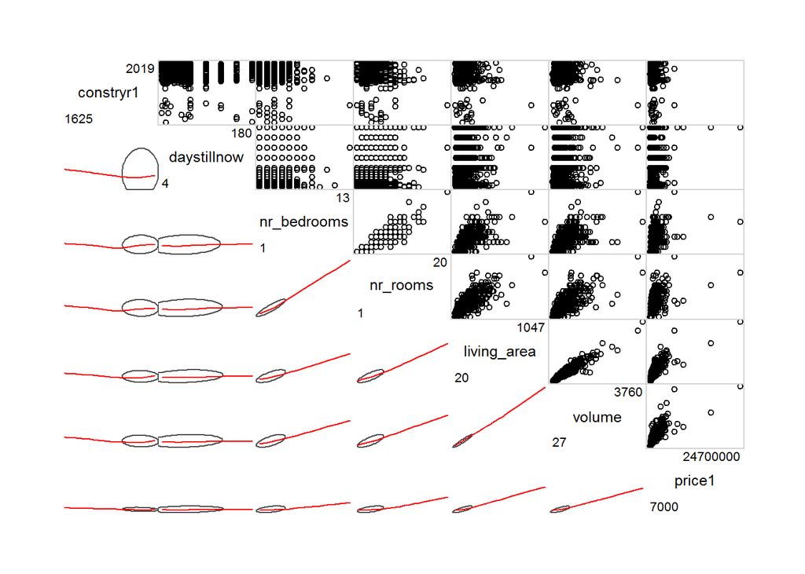

```r
# check the correlation between different variables
corrgram(data, order=TRUE, lower.panel=panel.ellipse, upper.panel=panel.pts,
         text.panel=panel.txt, diag.panel=panel.minmax)
```

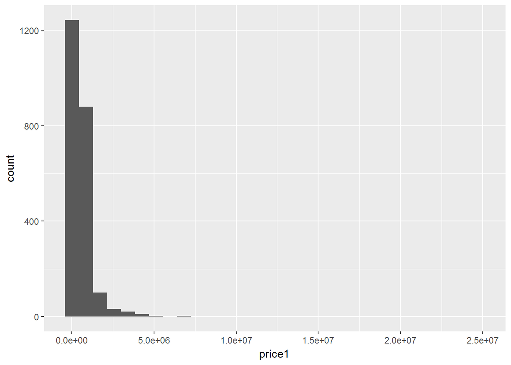

```r
# check the distribution of price
g <- ggplot(data, aes(x=price1))
g <- g + geom_histogram()
g
```

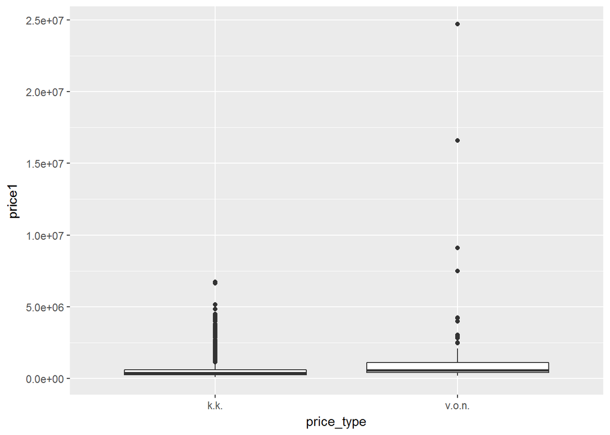

```r
# check if price_type has someting to do with price, yes it does
g <- ggplot(data[!is.na(data$living_area),], aes(x=price_type, y=price1))
g <- g + geom_boxplot()
g
```

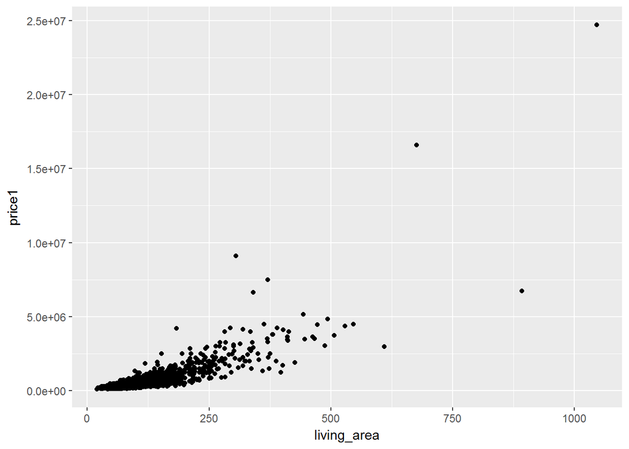

```r
# check the correlation between price and living_area
g <- ggplot(data[!is.na(data$living_area),], aes(x=living_area, y=price1))
g <- g + geom_point()
g
```

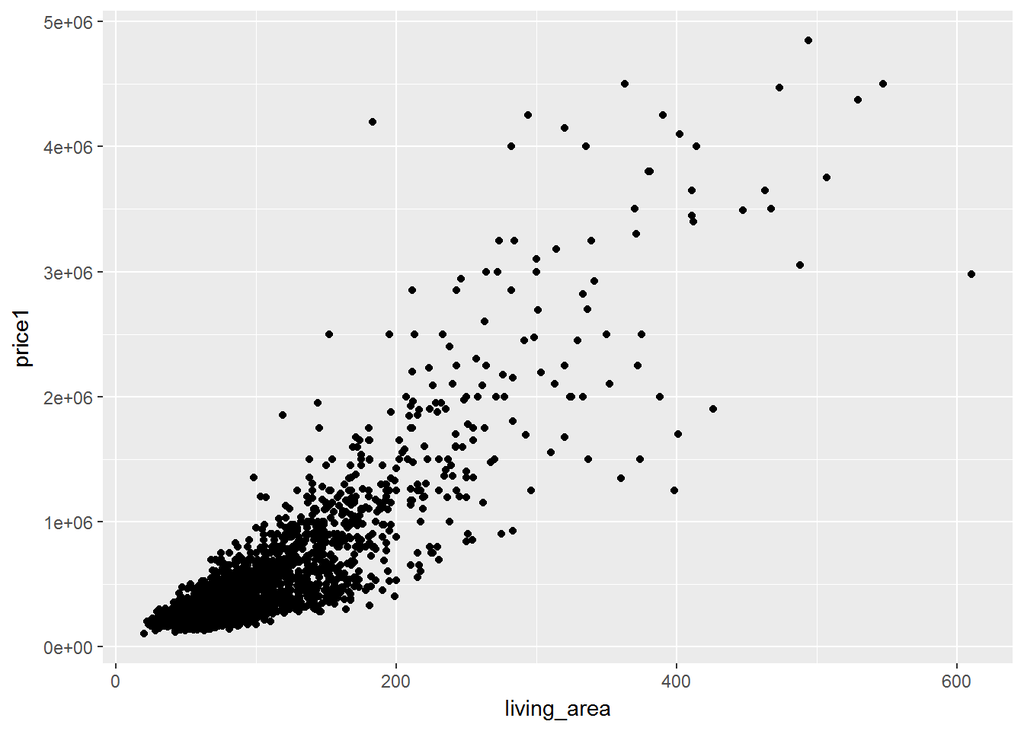

```r
# outliers can be spoted, remove and try again
g <- ggplot(data[!is.na(data$living_area) & data$price1<5E6,], aes(x=living_area, y=price1))
g <- g + geom_point()
g
```

```r
# it is better to remove price1 over 5E6, just a few observations
table((data$price1>5E6))
```

```
##
## FALSE  TRUE
##  2288     7
```

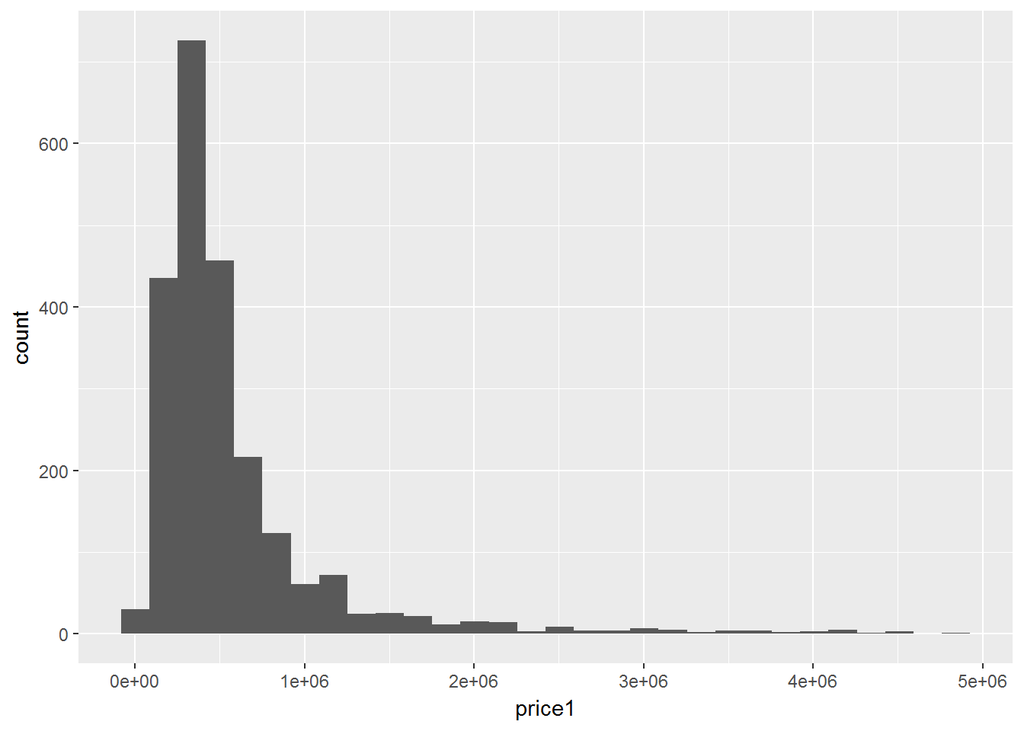

```r
data <- data[data$price1<5E6,]

# check the distribution of price again after removing outlier
g <- ggplot(data, aes(x=price1))
g <- g + geom_histogram()
g
```

```r
# check the correlation among price, living area and volume
cor(data[,c("price1","living_area","volume")], use="complete.obs")
```

```
##                price1 living_area    volume
## price1      1.0000000   0.8582371 0.8384802
## living_area 0.8582371   1.0000000 0.9516635
## volume      0.8384802   0.9516635 1.0000000
```

```r
# it appears that living_area is closer to price
# can consider to create a new feature which represent height
# also can use median height to recode living_area

data4av <- data[!(is.na(data$volume)|is.na(data$living_area)),c("price1","volume","living_area")]
data4av$height <- as.numeric(data4av$volume/data4av$living_area)
median_height <- median(data4av$height)
median_height
```

```
## [1] 3.164421
```

```r
data$living_area[is.na(data$living_area) & !is.na(data$volume)] <- data$volume[is.na(data$living_area) & !is.na(data$volume)] / median_height

data$height[!is.na(data$living_area)] <- as.numeric(data$volume[!is.na(data$living_area)]/data$living_area[!is.na(data$living_area)])
table(is.na(data$living_area))
```

```
##
## FALSE  TRUE
##  2256    32
```

```r
table(is.na(data$height))
```

```
##
## FALSE  TRUE
##  2256    32
```

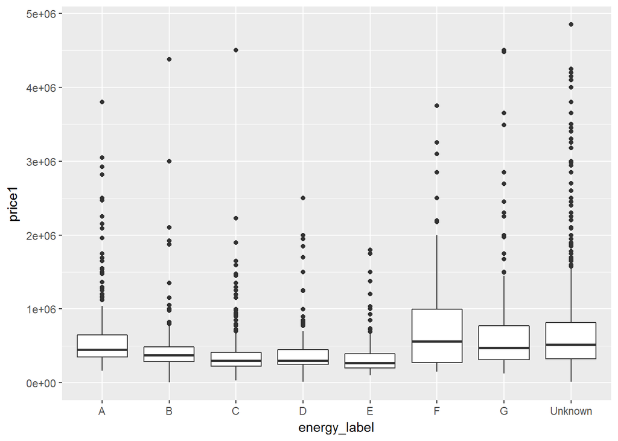

```r
# remove volume
data$volume <- NULL

# check the relationship between price and energy label
g <- ggplot(data[!is.na(data$energy_label), ], aes(x=energy_label, y=price1))
g <- g + geom_boxplot()
g
```

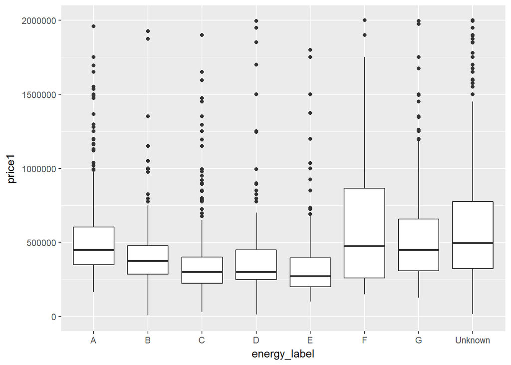

```r
# check only price < 2E6, it is clearer that energy label has something to do with price
g <- ggplot(data[!is.na(data$energy_label), ], aes(x=energy_label, y=price1))
g <- g + geom_boxplot()
g <- g + ylim(0, 2E6)
g
```

```r
# still a lot observations with price > 2E6, better to keep it
table((data$price1>2E6))
```

```
##
## FALSE  TRUE
##  2217    71
```

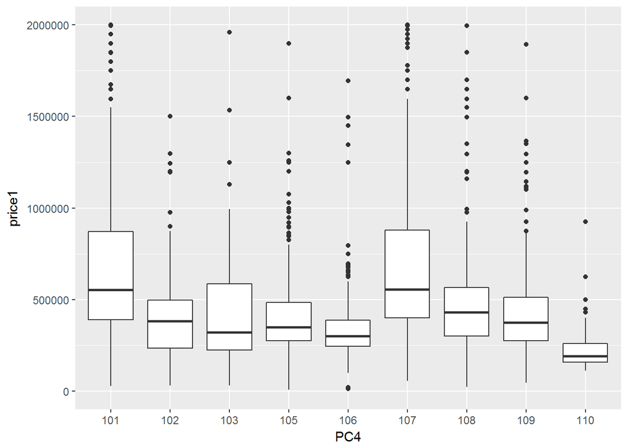

```r
# check the relationship between price and PC4
g <- ggplot(data[!is.na(data$PC4), ], aes(x=PC4, y=price1))
g <- g + geom_boxplot()
g <- g + ylim(0, 2E6)
g
```

```r
# check the correlation among price1, nr_rooms and nr_bedrooms
cor(data[,c("price1","nr_rooms","nr_bedrooms")], use="complete.obs")
```

```
##                price1  nr_rooms nr_bedrooms
## price1      1.0000000 0.6305041   0.4986200
## nr_rooms    0.6305041 1.0000000   0.9039402
## nr_bedrooms 0.4986200 0.9039402   1.0000000
```

```r
# since nr_bedrooms has high correlation with nr_rooms, better to keep only nr_rooms
# create another feature nr_other_rooms
data$nr_other_rooms <- data$nr_rooms - data$nr_bedrooms
cor(data[,c("price1","nr_rooms","nr_bedrooms","nr_other_rooms")], use="complete.obs")
```

```
##                   price1  nr_rooms nr_bedrooms nr_other_rooms
## price1         1.0000000 0.6305041   0.4986200      0.5872978
## nr_rooms       0.6305041 1.0000000   0.9039402      0.7593831
## nr_bedrooms    0.4986200 0.9039402   1.0000000      0.4081833
## nr_other_rooms 0.5872978 0.7593831   0.4081833      1.0000000
```

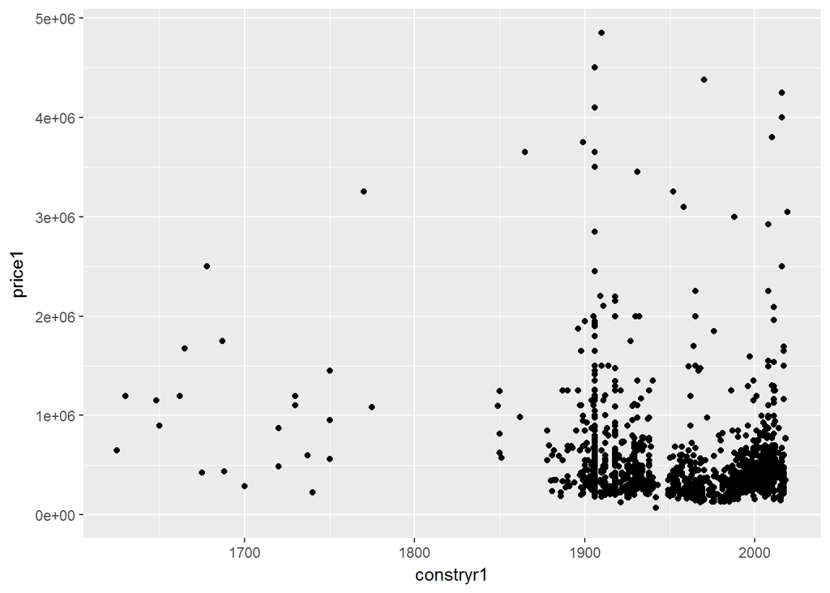

```r
# the new feature has higher correlation with price, but lower with nr_rooms
data$nr_bedrooms <- NULL

# if built long ago, then it won't be very expensive
g <- ggplot(data=data, aes(x=constryr1, y=price1))
g <- g + geom_point()
g
```

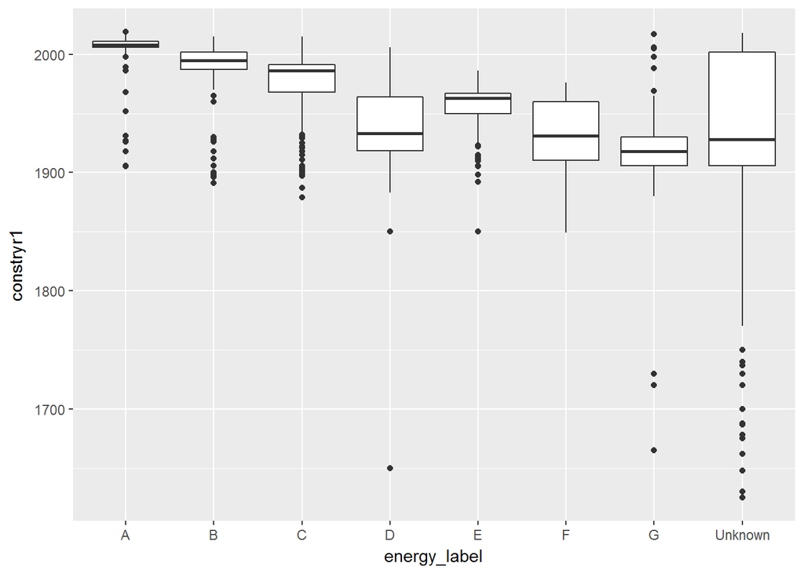

```r
# energy label has strong relationship with construction year
g <- ggplot(data=data, aes(x=energy_label, y=constryr1))
g <- g + geom_boxplot()
g
```

```r
# use energy label to recode construction year
data$constryr3 <- !is.na(data$constryr1)
table(data$constryr3, data$energy_label)
```

```
##
##           A   B   C   D   E   F   G Unknown
##   FALSE 135  76 104  73  66  33  84     359
##   TRUE  195 154 239 102 142  51 109     366
```

```r
data %>% filter(!is.na(constryr1)) %>%
    group_by(energy_label) %>% summarise(builtyear=median(constryr1))
```

```
## # A tibble: 8 x 2
##   energy_label builtyear
##          <chr>     <dbl>
## 1            A      2008
## 2            B      1995
## 3            C      1986
## 4            D      1933
## 5            E      1963
## 6            F      1931
## 7            G      1918
## 8      Unknown      1928
```

```r
data$constryr1[data$energy_label=="A" & is.na(data$constryr1)] <- 2005
data$constryr1[data$energy_label=="B" & is.na(data$constryr1)] <- 1995
data$constryr1[data$energy_label=="C" & is.na(data$constryr1)] <- 1986
data$constryr1[data$energy_label=="D" & is.na(data$constryr1)] <- 1933
data$constryr1[data$energy_label=="E" & is.na(data$constryr1)] <- 1963
data$constryr1[data$energy_label=="F" & is.na(data$constryr1)] <- 1931
data$constryr1[data$energy_label=="G" & is.na(data$constryr1)] <- 1918
data$constryr1[data$energy_label=="Unknown" & is.na(data$constryr1)] <- 1928

data$yeartodate <- year(Sys.Date()) - data$constryr1
table(is.na(data$yeartodate))
```

```
##
## FALSE
##  2288
```

```r
table(data$yeartodate)
```

```
##
##  -2  -1   0   1   2   3   4   5   6   7   8   9  10  11  12  13  14  15
##   1   3  30  12   8  10   2   5  39  23  16  38  24  43 152  20  10  19
##  16  17  18  19  20  21  22  23  24  25  26  27  28  29  30  31  32  33
##  10   5  18  24   7  10  97   7  14  16   8  21  16   9   9 134  11  10
##  34  35  36  37  38  39  40  41  42  43  44  45  46  47  48  49  50  51
##   6   7   6   7   1   2   1  18   3   3   3   2   1   8  19  14  10   5
##  52  53  54  55  56  57  58  59  60  61  62  63  64  65  67  68  74  75
##  38   5  78  13   6   9   5   4   7   6   7   7   2  13   4   4   1   2
##  77  78  79  80  81  82  83  84  85  86  87  88  89  90  91  92  93  94
##  11   3  19   8   2   4  12  84   6  48  13  23 367   8   7  16   6   3
##  95  96  97  98  99 101 102 103 104 105 106 107 108 111 112 113 114 115
##   6   5   5   1 136   6   3   4   3  16   7   6   4 115  11   8   3   8
## 116 117 118 119 120 121 122 123 124 125 126 127 128 130 131 132 134 135
##   3  10   9   6   3   2   1   1   1   1   2   6   1   3   2   1   1   5
## 136 137 138 139 152 155 166 167 168 242 247 267 277 280 287 297 317 329
##   2   1   1   2   1   1   1   3   1   1   1   3   1   1   2   2   1   1
## 330 339 342 352 355 367 369 387 392
##   1   1   1   1   1   1   1   1   1
```

```r
data$constryr3 <- NULL
# some building will be built in the future

# yeartodate is significantly correlated with price, keep it
cor.test(data[,"price1"],data[,"yeartodate"])
```

```
##
##  Pearson's product-moment correlation
##
## data:  data[, "price1"] and data[, "yeartodate"]
## t = 8.8305, df = 2286, p-value < 2.2e-16
## alternative hypothesis: true correlation is not equal to 0
## 95 percent confidence interval:
##  0.1416964 0.2209553
## sample estimates:
##       cor
## 0.1816208
```

```r
# daystillnow is significantly correlated with price, keep it
cor.test(data[,"price1"],data[,"daystillnow"])
```

```
##
##  Pearson's product-moment correlation
##
## data:  data[, "price1"] and data[, "daystillnow"]
## t = 6.1034, df = 2286, p-value = 1.217e-09
## alternative hypothesis: true correlation is not equal to 0
## 95 percent confidence interval:
##  0.08609311 0.16673924
## sample estimates:
##       cor
## 0.1266254
```

```r
names(data)
```

```
##  [1] "price1"         "price_type"     "living_area"    "nr_rooms"
##  [5] "energy_label"   "parking"        "constryr1"      "PC4"
##  [9] "daystillnow"    "height"         "nr_other_rooms" "yeartodate"
```

```r
dim(data)
```

```
## [1] 2288   12
```

```r
# check missing values
apply(data, 2, function(x) sum(is.na(x)))
```

```
##         price1     price_type    living_area       nr_rooms   energy_label
##              0              0             32             33              0
##        parking      constryr1            PC4    daystillnow         height
##              0              0              0              0             32
## nr_other_rooms     yeartodate
##             98              0
```

```r
data_clean <- data[-manyNAs(data), ]
apply(data_clean, 2, function(x) sum(is.na(x)))
```

```
##         price1     price_type    living_area       nr_rooms   energy_label
##              0              0              0              1              0
##        parking      constryr1            PC4    daystillnow         height
##              0              0              0              0              0
## nr_other_rooms     yeartodate
##             66              0
```

```r
table(data_clean$nr_other_rooms)
```

```
##
##    0    1    2    3    4    5    6    7    8
##   37 1643  359   85   37   16    8    4    1
```

```r
table(is.na(data_clean$nr_other_rooms))
```

```
##
## FALSE  TRUE
##  2190    66
```

```r
data4ratio <- data[!(is.na(data_clean$nr_rooms)|is.na(data_clean$nr_other_rooms)),c("nr_rooms","nr_other_rooms")]
median_ratio <- median(na.omit(data4ratio[,1] / data4ratio[,2]))
median_ratio
```

```
## [1] 3
```

```r
data_clean <- data_clean[!is.na(data_clean$nr_rooms),]
data_clean$nr_other_rooms[is.na(data_clean$nr_other_rooms)] <- round(data_clean$nr_rooms[is.na(data_clean$nr_other_rooms)]/median_ratio,0)

apply(data_clean, 2, function(x) sum(is.na(x)))
```

```
##         price1     price_type    living_area       nr_rooms   energy_label
##              0              0              0              0              0
##        parking      constryr1            PC4    daystillnow         height
##              0              0              0              0              0
## nr_other_rooms     yeartodate
##              0              0
```

```r
dim(data_clean)
```

```
## [1] 2255   12
```

```r
str(data_clean)
```

```
## 'data.frame':    2255 obs. of  12 variables:
##  $ price1        : int  599000 450000 1995000 1550000 298011 399000 325000 295000 250000 275000 ...
##  $ price_type    : chr  "k.k." "k.k." "k.k." "k.k." ...
##  $ living_area   : num  173 143 250 310 102 70 55 97 57 70 ...
##  $ nr_rooms      : int  6 6 6 6 4 3 3 3 3 2 ...
##  $ energy_label  : chr  "A" "D" "G" "A" ...
##  $ parking       : chr  "Paid" "Public" "Public" "Unknown" ...
##  $ constryr1     : num  2008 1967 1932 2008 1991 ...
##  $ PC4           : chr  "108" "106" "107" "108" ...
##  $ daystillnow   : num  4 10 14 42 60 6 9 7 9 9 ...
##  $ height        : num  3.43 4.55 3.51 3.23 3.37 ...
##  $ nr_other_rooms: num  1 1 2 2 1 1 1 1 1 1 ...
##  $ yeartodate    : num  9 50 85 9 26 101 77 7 90 9 ...
```

## Model comparison

Since quite some features seem to have linear relationship with independent variable, consider using linear regression, but also use decision tree as a validation.

```r
# prepare formula for model
covnames <- names(select(data_clean, -c(price1)))
form <- as.formula(paste("price1~", paste(covnames, collapse="+"), sep=""))
form
```

```
## price1 ~ price_type + living_area + nr_rooms + energy_label +
##     parking + constryr1 + PC4 + daystillnow + height + nr_other_rooms +
##     yeartodate
```

```r
# linear regression first

fit.lm <- lm(price1 ~ ., data_clean)
summary(fit.lm)
```

```
##
## Call:
## lm(formula = price1 ~ ., data = data_clean)
##
## Residuals:
##      Min       1Q   Median       3Q      Max
## -1851588   -98963      504    82268  2731731
##
## Coefficients: (1 not defined because of singularities)
##                       Estimate Std. Error t value Pr(>|t|)
## (Intercept)          993847.06  313576.03   3.169 0.001548 **
## price_typev.o.n.     114782.81   26481.14   4.335 1.53e-05 ***
## living_area            8202.16     131.92  62.175  < 2e-16 ***
## nr_rooms             -60182.27    5801.11 -10.374  < 2e-16 ***
## energy_labelB          1434.45   21623.24   0.066 0.947115
## energy_labelC         72945.48   20033.76   3.641 0.000278 ***
## energy_labelD         76536.39   25449.70   3.007 0.002665 **
## energy_labelE         85127.74   23082.93   3.688 0.000232 ***
## energy_labelF         73862.26   31512.18   2.344 0.019169 *
## energy_labelG         66345.80   25749.95   2.577 0.010043 *
## energy_labelUnknown   65179.27   19829.20   3.287 0.001028 **
## parkingPublic         14575.74   15313.58   0.952 0.341293
## parkingUnknown        29378.32   13318.53   2.206 0.027498 *
## constryr1              -619.58     156.99  -3.947 8.17e-05 ***
## PC4102              -274497.17   28371.90  -9.675  < 2e-16 ***
## PC4103              -231955.74   27906.02  -8.312  < 2e-16 ***
## PC4105               -69358.88   16388.03  -4.232 2.41e-05 ***
## PC4106              -301562.22   19066.07 -15.817  < 2e-16 ***
## PC4107                71492.77   17631.46   4.055 5.19e-05 ***
## PC4108              -202072.10   22425.67  -9.011  < 2e-16 ***
## PC4109               -94340.45   20804.02  -4.535 6.07e-06 ***
## PC4110              -282807.50   25437.53 -11.118  < 2e-16 ***
## daystillnow             -82.06     109.77  -0.748 0.454815
## height                39551.81   10292.84   3.843 0.000125 ***
## nr_other_rooms        42765.72    9836.48   4.348 1.44e-05 ***
## yeartodate                  NA         NA      NA       NA
## ---
## Signif. codes:  0 '***' 0.001 '**' 0.01 '*' 0.05 '.' 0.1 ' ' 1
##
## Residual standard error: 237900 on 2230 degrees of freedom
## Multiple R-squared:  0.8302, Adjusted R-squared:  0.8284
## F-statistic: 454.3 on 24 and 2230 DF,  p-value: < 2.2e-16
```

```r
fit.lm2 <- lm(price1 ~ . - yeartodate, data_clean)
summary(fit.lm2)
```

```
##
## Call:
## lm(formula = price1 ~ . - yeartodate, data = data_clean)
##
## Residuals:
##      Min       1Q   Median       3Q      Max
## -1851588   -98963      504    82268  2731731
##
## Coefficients:
##                       Estimate Std. Error t value Pr(>|t|)
## (Intercept)          993847.06  313576.03   3.169 0.001548 **
## price_typev.o.n.     114782.81   26481.14   4.335 1.53e-05 ***
## living_area            8202.16     131.92  62.175  < 2e-16 ***
## nr_rooms             -60182.27    5801.11 -10.374  < 2e-16 ***
## energy_labelB          1434.45   21623.24   0.066 0.947115
## energy_labelC         72945.48   20033.76   3.641 0.000278 ***
## energy_labelD         76536.39   25449.70   3.007 0.002665 **
## energy_labelE         85127.74   23082.93   3.688 0.000232 ***
## energy_labelF         73862.26   31512.18   2.344 0.019169 *
## energy_labelG         66345.80   25749.95   2.577 0.010043 *
## energy_labelUnknown   65179.27   19829.20   3.287 0.001028 **
## parkingPublic         14575.74   15313.58   0.952 0.341293
## parkingUnknown        29378.32   13318.53   2.206 0.027498 *
## constryr1              -619.58     156.99  -3.947 8.17e-05 ***
## PC4102              -274497.17   28371.90  -9.675  < 2e-16 ***
## PC4103              -231955.74   27906.02  -8.312  < 2e-16 ***
## PC4105               -69358.88   16388.03  -4.232 2.41e-05 ***
## PC4106              -301562.22   19066.07 -15.817  < 2e-16 ***
## PC4107                71492.77   17631.46   4.055 5.19e-05 ***
## PC4108              -202072.10   22425.67  -9.011  < 2e-16 ***
## PC4109               -94340.45   20804.02  -4.535 6.07e-06 ***
## PC4110              -282807.50   25437.53 -11.118  < 2e-16 ***
## daystillnow             -82.06     109.77  -0.748 0.454815
## height                39551.81   10292.84   3.843 0.000125 ***
## nr_other_rooms        42765.72    9836.48   4.348 1.44e-05 ***
## ---
## Signif. codes:  0 '***' 0.001 '**' 0.01 '*' 0.05 '.' 0.1 ' ' 1
##
## Residual standard error: 237900 on 2230 degrees of freedom
## Multiple R-squared:  0.8302, Adjusted R-squared:  0.8284
## F-statistic: 454.3 on 24 and 2230 DF,  p-value: < 2.2e-16
```

```r
anova(fit.lm,fit.lm2)
```

```
## Analysis of Variance Table
##
## Model 1: price1 ~ price_type + living_area + nr_rooms + energy_label +
##     parking + constryr1 + PC4 + daystillnow + height + nr_other_rooms +
##     yeartodate
## Model 2: price1 ~ (price_type + living_area + nr_rooms + energy_label +
##     parking + constryr1 + PC4 + daystillnow + height + nr_other_rooms +
##     yeartodate) - yeartodate
##   Res.Df        RSS Df Sum of Sq F Pr(>F)
## 1   2230 1.2626e+14
## 2   2230 1.2626e+14  0         0
```

```r
# remove yeartodate, and the model will not be affected

vif(fit.lm2)
```

```
##                    GVIF Df GVIF^(1/(2*Df))
## price_type     1.318305  1        1.148174
## living_area    3.019399  1        1.737642
## nr_rooms       4.187238  1        2.046274
## energy_label   2.629669  7        1.071502
## parking        1.300560  2        1.067905
## constryr1      2.042926  1        1.429310
## PC4            2.260670  8        1.052301
## daystillnow    1.107257  1        1.052263
## height         1.054873  1        1.027070
## nr_other_rooms 2.618321  1        1.618123
```

```r
# regression tree

set.seed(123)
library(rpart)
fit.rt <- rpart(form, data_clean)
fit.rt
```

```
## n= 2255
##
## node), split, n, deviance, yval
##       * denotes terminal node
##
##  1) root 2255 7.435781e+14  582878.8
##    2) living_area< 201 2091 1.739798e+14  463480.6
##      4) living_area< 112.5924 1518 3.427009e+13  357150.6
##        8) living_area< 74.5 758 6.916589e+12  285581.1 *
##        9) living_area>=74.5 760 1.959847e+13  428531.8
##         18) PC4=102,103,106,108,110 334 3.021997e+12  306948.3 *
##         19) PC4=101,105,107,109 426 7.768031e+12  523857.8 *
##      5) living_area>=112.5924 573 7.707957e+13  745171.7
##       10) PC4=102,103,106,108,110 271 1.292314e+13  521230.0 *
##       11) PC4=101,105,107,109 302 3.837024e+13  946126.1 *
##    3) living_area>=201 164 1.597224e+14 2105206.0
##      6) living_area< 271.5 96 3.046207e+13 1586061.0 *
##      7) living_area>=271.5 68 6.686054e+13 2838116.0
##       14) PC4=102,103,106,110 7 5.407949e+11 1301143.0 *
##       15) PC4=101,105,107,108,109 61 4.788616e+13 3014490.0
##         30) living_area< 357.5 34 1.853416e+13 2632794.0 *
##         31) living_area>=357.5 27 1.816069e+13 3495145.0 *
```

```r
# random forest takes too much time to run
# first compare linear regression and regression trees

# compare models

cv.rpart <- function(form,train,test,...){
    m <- rpartXse(form,train, ...)
    p <- predict(m,test)
    mse <- mean((p-resp(form,test))^2)
    c(nmse=mse/mean((mean(resp(form, train))-resp(form,test))^2))
}

cv.lm <- function(form,train,test,...){
    m <- lm(form,train,...)
    p <- predict(m,test)
    p <- ifelse(p<0,0,p)
    mse <- mean((p-resp(form,test))^2)
    c(nmse=mse/mean((mean(resp(form,train))-resp(form,test))^2))
}

res <- experimentalComparison(
    c(dataset(form, data_clean,'price1')),
    c(variants('cv.lm'),
      variants('cv.rpart',se=c(0,0.5,1))),
    cvSettings(3,10,123))
```

[output not shown]

```
##   2
```

```
##   3
```

```
##   4
```

```
##   5
```

```
##   6
```

```
##   7
```

```
##   8
```

```
##   9
```

```
##   10
```

[output not shown]

```
##   2
```

```
##   3
```

```
##   4
```

```
##   5
```

```
##   6
```

```
##   7
```

```
##   8
```

```
##   9
```

```
##   10
```

[output not shown]

```
##   2
```

```
##   3
```

```
##   4
```

```
##   5
```

```
##   6
```

```
##   7
```

```
##   8
```

```
##   9
```

```
##   10
```

[output not shown]

```r
# compare the results
summary(res)
```

```
##
## == Summary of a  Cross Validation  Experiment ==
##
##  3 x 10 - Fold Cross Validation run with seed =  123
##
## * Data sets ::  price1
## * Learners  ::  cv.lm.v1, cv.rpart.v1, cv.rpart.v2, cv.rpart.v3
##
## * Summary of Experiment Results:
##
##
## -> Datataset:  price1
##
##  *Learner: cv.lm.v1
##               nmse
## avg     0.17978692
## std     0.04745173
## min     0.11010226
## max     0.31602287
## invalid 0.00000000
##
##  *Learner: cv.rpart.v1
##               nmse
## avg     0.24353443
## std     0.06809026
## min     0.15323956
## max     0.37740740
## invalid 0.00000000
##
##  *Learner: cv.rpart.v2
##              nmse
## avg     0.2420776
## std     0.0660764
## min     0.1487605
## max     0.3882235
## invalid 0.0000000
##
##  *Learner: cv.rpart.v3
##               nmse
## avg     0.25752349
## std     0.06755558
## min     0.13790605
## max     0.38822346
## invalid 0.00000000
```

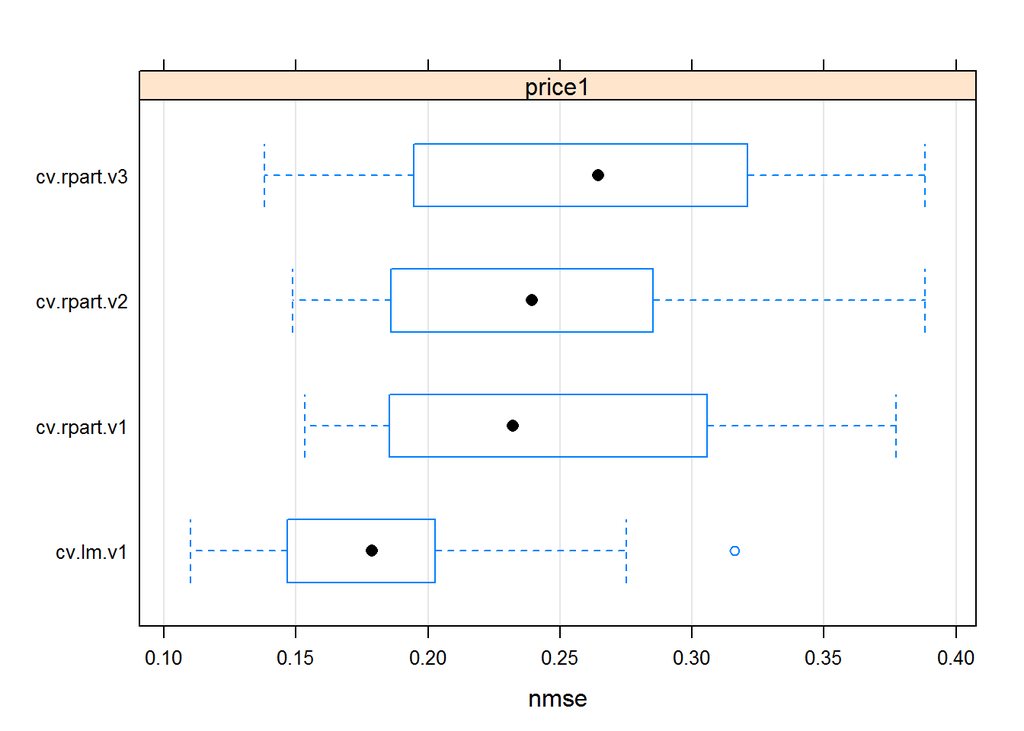

```r
# linear regression is obviously better than regression trees
plot(res)
```

```r
bestScores(res)
```

```
## $price1
##        system     score
## nmse cv.lm.v1 0.1797869
```

## Conclusion

Linear regression is the best model for the task.